# Birds Canada Chilcotin ARU Analysis

Sunny Tseng

2024-12-31

## **Overview**

This project was contracted to Sunny Tseng by Birds Canada, with the goal of processing the audio data collected by Birds Canada in the field and providing a descriptive report on the detections. This document serves as the final report, summarizing the methods employed in the analysis and presenting the results. All R code developed during the project is available on the “[Birds Canada ARU 2024](https://github.com/SunnyTseng/Birds-Canada-ARU-2024/tree/main)” GitHub page.

```r
# required packages if you are following the code
library(tidyverse)
library(here)
```

## **Audio data & BirdNET processing**

Audio data were collected during the bird breeding seasons (May to July) of 2023 and 2024 in the Chilcotin Cariboo region of British Columbia, Canada. In 2023, 19 sites were surveyed, with each site monitored at one or two locations (a total of 36 locations). In 2024, the survey expanded to 20 sites, each with two monitored locations (a total of 40 locations). Approximately 6 TB of audio recordings were gathered over the two years. Data collection employed two models of Autonomous Recording Units (ARUs): the BAR-LT from Frontier Labs and the Song Meter Mini from Wildlife Acoustics.

All audio data were analyzed using BirdNET (model v2.4) with the original Python code from the [BirdNET Analyzer GitHub repository](https://github.com/kahst/BirdNET-Analyzer). Analyses were performed on a desktop computer using Visual Studio Code. While BirdNET parameters were largely kept at their default settings, specific adjustments included `result_type = "r"`, `batch_size = 4`, and `threads = 4`. To maximize detections, a minimum confidence threshold of 0.1 was applied. Processing the full 6 TB of audio data required approximately 72 hours of computer time.

## **All species - raw output & effort**

The initial BirdNET analysis identified a total of 9,244,102 detections across 5,802 classes, including birds, non-birds, and non-animal sounds. The complete dataset is available for download from the project’s GitHub page in `.rda` file format. To load and view the dataset in R, use the following line of code:

```r
# edit file path as needed
load(here("data", "BirdNET_detections", "detections_2023_2024.rda"))
```

The surveying effort (i.e., whether the ARU at a given site is active on a specific date) is essential for analyzing data and making inferences. I have summarized the number of active ARUs on each specific date across two years of surveys. The raw summarized effort data can be loaded using the following line of code:

```r
# edit file path as needed
load(here("data", "effort", "effort_final.rda"))
```

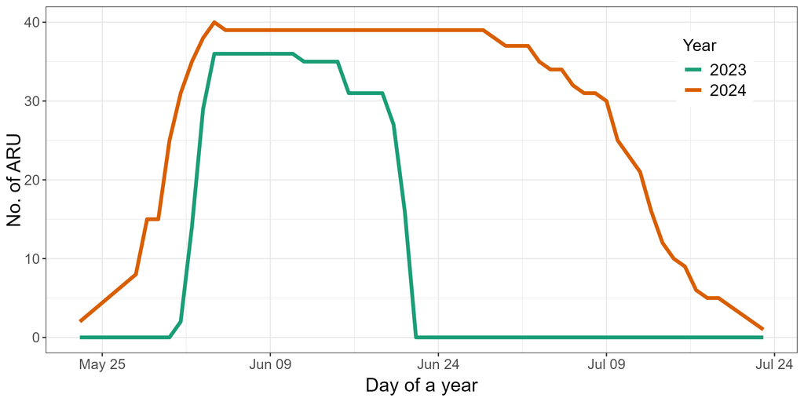

For data quick review, I filtered the detections using the bird species list from the [Atlas of the Breeding Birds of British Columbia](https://www.birdatlas.bc.ca/bcdata/datasummaries.jsp?extent=Prov&summtype=SpList&year=allyrs&byextent1=Prov&byextent2=Sq&region2=1&squarePC=&region1=0&square=&region3=0&lang=en), which includes 329 bird species recorded in the province. It is important to note that these detections have not yet been validated, so we cannot confirm that they represent the total number of species detected in the study area. However, these provide an overview of the number of detections and species across different sites.

A comprehensive species validation process is required to accurately verify species richness. Although this validation was not performed in the current analysis, it can be achieved by selecting the top 5 or 10 detections for each species and verifying their presence. This approach would provide a more reliable estimate of the species richness in the study area.

|  | year | site | No. location | Detections | No. BC species |
| --- | --- | --- | --- | --- | --- |
| 1 | 2023 | Axe Lake | 2 | 110103 | 255 |
| 2 | 2023 | Baptiste Meadow | 2 | 131101 | 287 |
| 3 | 2023 | Big Creek Control | 2 | 58160 | 241 |
| 4 | 2023 | Brunson Lake | 2 | 115072 | 270 |
| 5 | 2023 | Chilco Ranch | 2 | 83460 | 262 |
| 6 | 2023 | Colpitt Lake | 2 | 114323 | 266 |
| 7 | 2023 | Dog Creek Road | 2 | 105756 | 255 |
| 8 | 2023 | Enterprise Road | 1 | 64408 | 204 |
| 9 | 2023 | Fiftynine Creek | 2 | 161072 | 252 |
| 10 | 2023 | Helena Conservation | 2 | 117290 | 237 |

[output cut: 29 more lines]

## **Focal species - validated output**

### Background

A total of 27 species were identified as focal species for this analysis. These focal species are:

```
##  [1] "American Bittern"    "American Coot"       "American Wigeon"
##  [4] "Barrow's Goldeneye"  "Black Tern"          "Bufflehead"
##  [7] "Eared Grebe"         "Green-winged Teal"   "Horned Grebe"
## [10] "Mallard"             "Pied-billed Grebe"   "Redhead"
## [13] "Red-necked Grebe"    "Ring-necked Duck"    "Ruddy Duck"
## [16] "Sora"                "Trumpeter Swan"      "Virginia Rail"
## [19] "White-winged Scoter" "Yellow Rail"         "Band-tailed Pigeon"
## [22] "Common Nighthawk"    "Evening Grosbeak"    "Flammulated Owl"
## [25] "Rusty Blackbird"     "Sharp-tailed Grouse" "Townsend's Warbler"
```

```r
# edit file path as needed
load(here("data", "BirdNET_detections", "detections_2023_2024_focal.rda"))
```

The objective of selecting these focal species is to identify BirdNET species-specific thresholds. The aim of setting species-specific threshold is to maximize true-positive detections while minimizing false-positives. To achieve this, we applied the methods proposed by [Wood and Kahl (2024)](https://link.springer.com/article/10.1007/s10336-024-02144-5) and [Tseng et al. (2024)](https://github.com/SunnyTseng/thesis_aru_BirdNET_evaluation/blob/main/R/Ch1_10_step_by_step_tutorial/species_specific_method_tutorial.md) for establishing species-specific thresholds for BirdNET.

### Validation process

We selected 180 nine-second recording segments using stratified random sampling across confidence values for each target species. Subsequently, we validated whether these recordings were true positives (indicating the target species was present) or false positives (indicating the target species was absent).

Sunny Tseng, David Bradley, and Remi Torrenta participated in the validation process. Sunny drafted the [validation protocol](https://github.com/SunnyTseng/Birds-Canada-ARU-2024/blob/main/docs/project_report_11_19_species_validation_with_ShinyR.md) and designed an R Shiny app that supports both audio playback and spectrogram viewing. The validation process was conducted in November and December 2024. The allocation of species among the three participants can be found in this [spreadsheet](https://docs.google.com/spreadsheets/d/1Ulb9EUYBQRwxg-WvMJjte0vJT6bJMl6n/edit?gid=554288332#gid=554288332). The validated files can be accessed by:

```r
list.files(here("data", "validation_recordings", "z_finished_files"), full.name = TRUE) %>%
  map_dfr(read_csv)
```

### Calibration curve

Using the validated dataset, I employed a generalized linear model with a binomial distribution to analyze the relationship between true/false positives (response variable) and BirdNET confidence values (predictor variables). This analysis will allow us to determine how BirdNET confidence relates to true positive detections. The calibration curves for each species indicate that most species can achieve a probability of being a true positive of approximately 0.75 when the BirdNET confidence value ranges from 0.25 to 0.40.

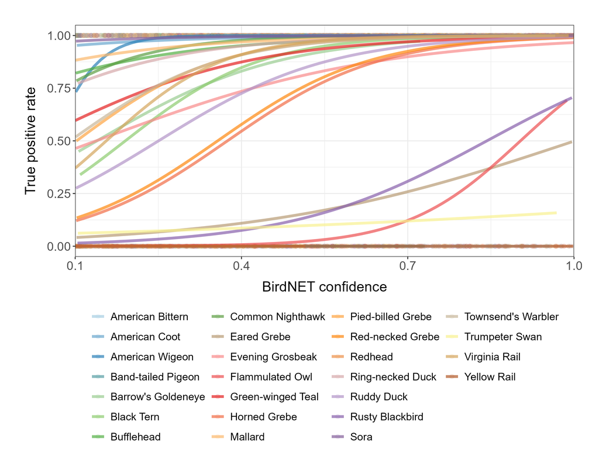

### Species-specific thresholds (precision = 0.9, 0.95, 0.99)

To determine species-specific thresholds, I back-transformed the model output to predict the probability of each BirdNET detection being a true positive based on the reported confidence value. I then identified the confidence threshold required to achieve a certain precision (i.e., 0.9, 0.95, 0.99), meaning the percentage of detections retained after applying this threshold were true positives. For detailed methods, refer to [Tseng et al. (2024)](https://github.com/SunnyTseng/thesis_aru_BirdNET_evaluation/blob/main/R/Ch1_10_step_by_step_tutorial/species_specific_method_tutorial.md).

A confidence threshold equals to one representing the Generalized Linear Model did not converge successfully.

|  | common_name | t_0.9 | t_0.95 | t_0.99 |
| --- | --- | --- | --- | --- |
| 1 | American Bittern | 1 | 1 | 1 |
| 2 | American Coot | 0.1 | 0.1 | 0.254 |
| 3 | American Wigeon | 0.1 | 0.1 | 0.118 |
| 4 | Band-tailed Pigeon | 1 | 1 | 1 |
| 5 | Barrow's Goldeneye | 0.39 | 0.523 | 0.817 |
| 6 | Black Tern | 0.198 | 0.31 | 0.556 |
| 7 | Bufflehead | 0.1 | 0.24 | 0.605 |
| 8 | Common Nighthawk | 0.1 | 0.1 | 0.194 |
| 9 | Eared Grebe | 1 | 1 | 1 |
| 10 | Evening Grosbeak | 0.462 | 0.723 | 1 |

[output cut: 15 more lines]

### Daily activity (after applying species-specific threshold with precision = 0.95)

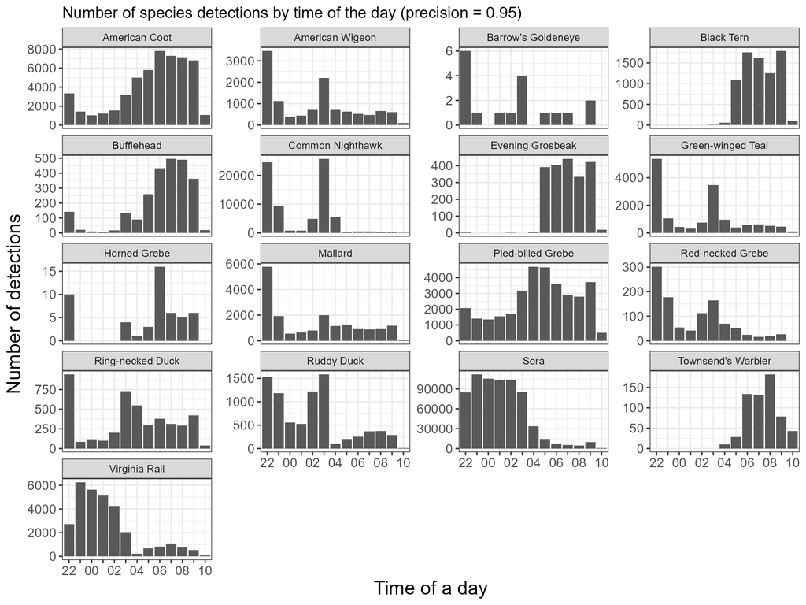

### Seasonal activity (after applying species-specific threshold with precision = 0.95)

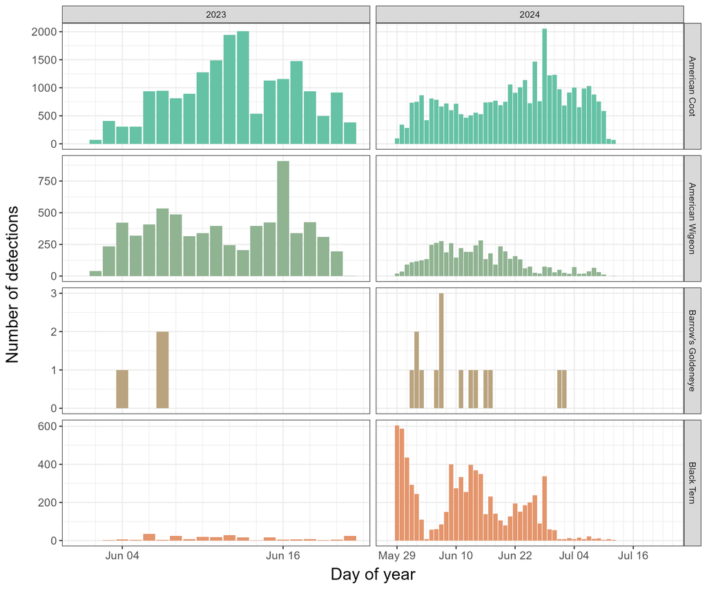

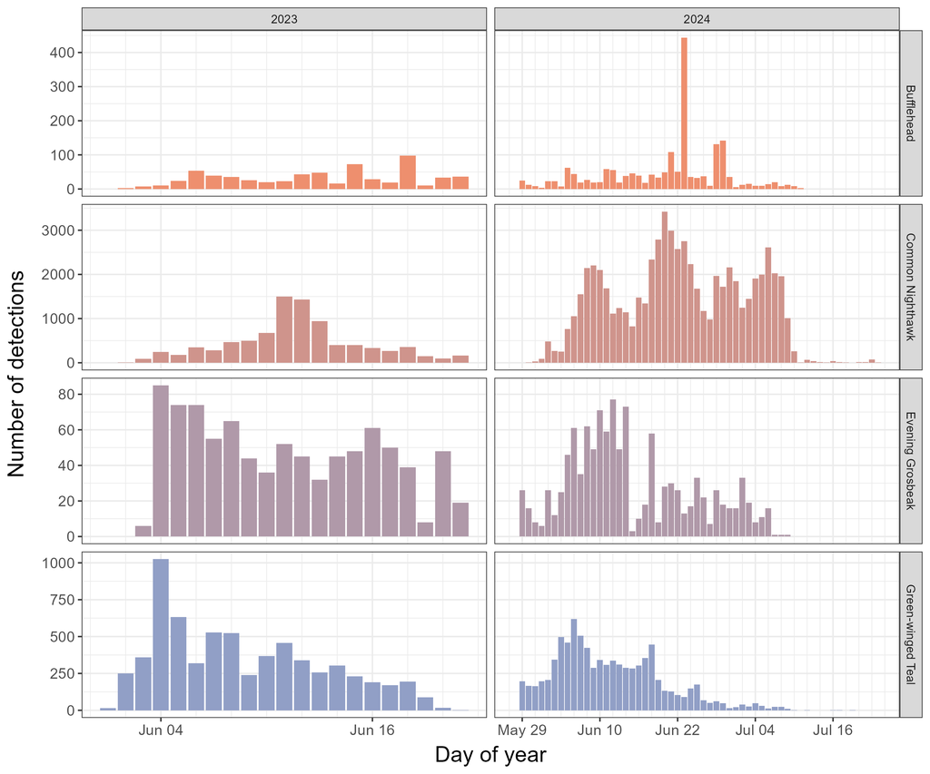

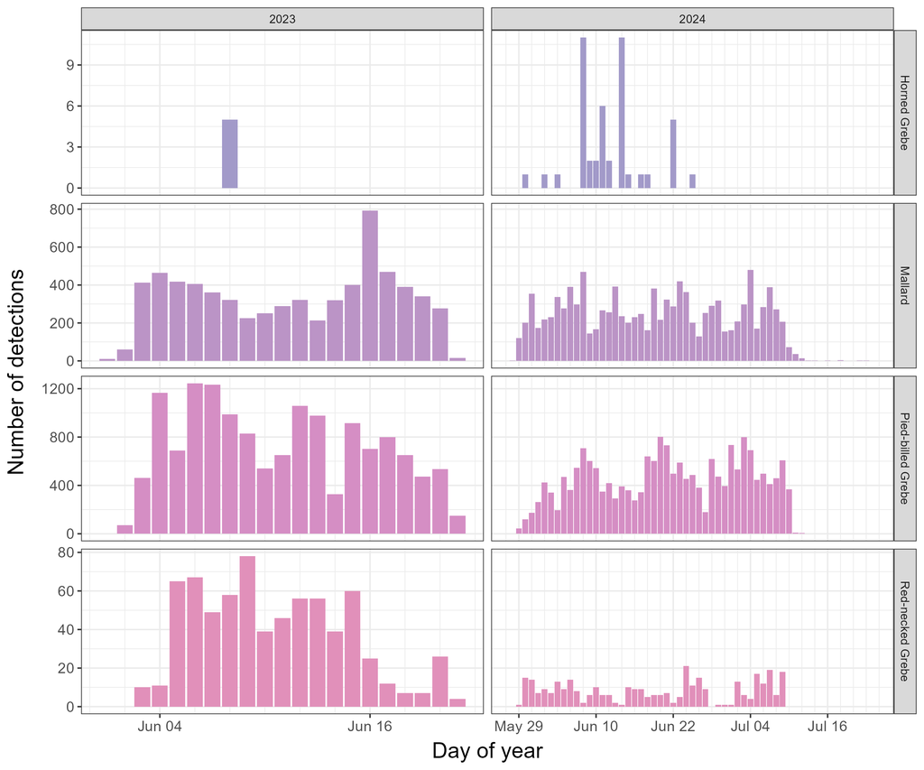

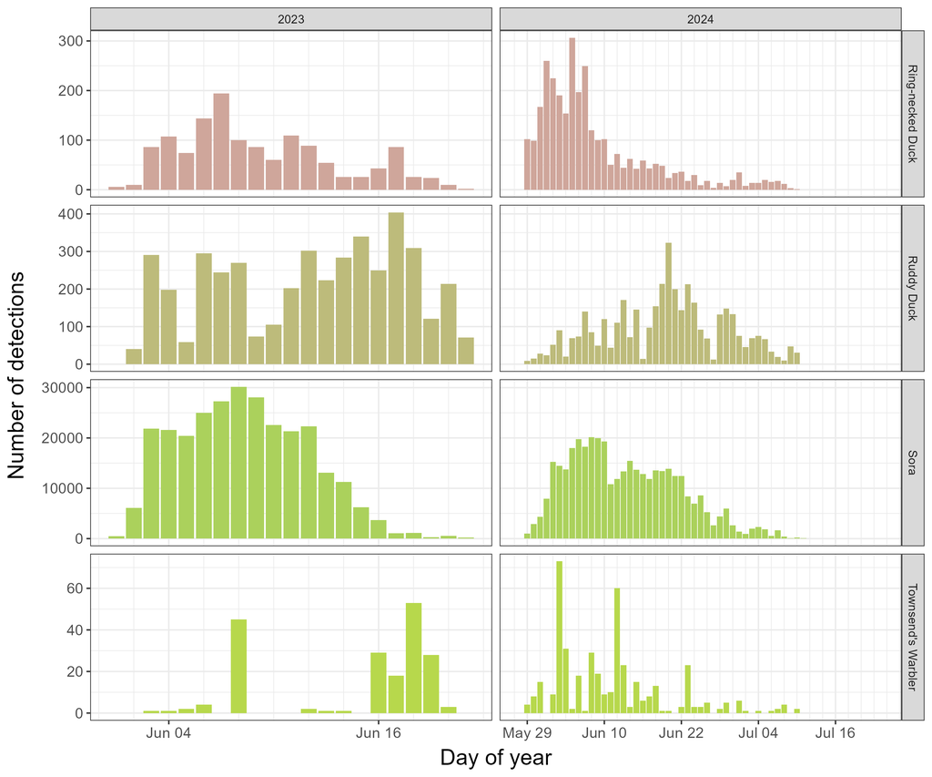

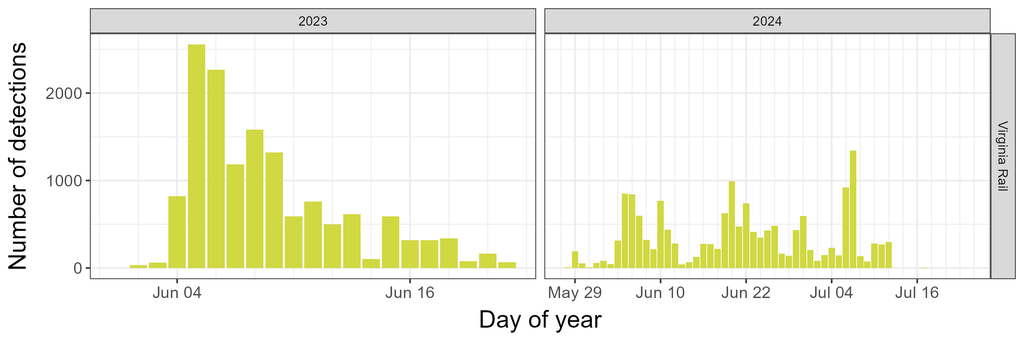